# Movement under uniform and constant electromagnetic fields

# Abstract

In this notebook we study the individual movement of charged particles under the influence of constant and uniform magnetic and electric fields. We introduce the *cyclotron frequency*, *Larmor radius*, *magnetic moment* and the *drift velocity* originated by crossed electric and magnetic field.

# Contents

1. Force on a single particle
2. Movement without $\vec{E}$ field
3. Magnetic Moment
4. $\vec{E} \neq \vec{0}$ but constant
5. General force, $\vec{F}$

# References

The subject of this notebook is covered in the bibliography in the following chapters:

> - F. Chen: *Single-particle Motions*, chapter 2, section 2.2
> - D. Nicholson: *Single-particle Motion*, chapter 2, section 2.2
> - J. Bittencourt: *Charged particle motion in constant and uniform electromagnetic fields*, chapter 2
> - R. Goldston: *Single-particle motion*, chapter 2

The examples are prepared with the help of the scientific software packages, *Scipy* and *IPython*, *Matplotlib* and the *Jupyter* notebook.

# 1. Force on a single particle

A particle with charge $q$ and mass $m$, moving with velocity $\vec{v}$, under electric, $\vec{E}$, and magnetic fields, $\vec{B}$, experiences a force given by the Lorentz force equation, $$ \vec{F} = q\left(\vec{E}+\vec{v}\times\vec{B}\right) \tag{Lorentz force}$$

# 2. Movement without $\vec{E}$ field

Let's keep it simple: $\vec{B}(\vec{r},t) = B_0\vec{u}_\parallel;\quad \vec{v}_0 = v_{\perp,0}\vec{u}_\perp+v_{z,0}\vec{u}_\parallel$ and we take $\vec{u}_\parallel \equiv \vec{u}_z$.

- The Lorentz force is $$ \vec{F} = q\vec{v}\times\vec{B}$$ and, as $\vec{F} \perp \vec{v} \Rightarrow$ constant kinetic energy, $W$: $$ m\vec{v}\cdot\frac{d\vec{v}}{dt}=\frac{d}{dt}\left(\frac{1}{2}mv^2\right)=0$$

## How is the movement?

1. In cartesian coordinates, the components of the Lorentz force equation are,

\begin{align} \dot{v}_x &= \frac{q}{m}v_y B_0 \\ \dot{v}_y &= -\frac{q}{m}v_x B_0 \\ \dot{v}_z &= 0 \end{align}

1. Taking the first two equations for *x* or *y*, differentiating and replacing terms we obtain the homogeneous equations:

\begin{align} \ddot{v}_{x} + \left(\frac{q}{m}B_0\right)^2 v_{x} &= 0 \\ \ddot{v}_{y} + \left(\frac{q}{m}B_0\right)^2 v_{y} &= 0 \end{align}

This is the equation for a *harmonic oscilator* with a frequency $\omega = q B_0/m$: In the *xy* plane, the particle describes a circle.

Integrating we obtain \begin{align} v_x &= v_\perp \exp(i{\color{green}{\omega_c}}t+i\delta) \\ v_y &= \pm i v_\perp \exp(i{\color{green}{\omega_c}}t+i\delta) \\ v_z &= v_{z,0} \end{align} with $v_\perp=(v_{x,0}^2+v_{y,0}^2)^{1/2}$, $\delta=\mp\tan^{-1}(v_{y,0}/v_{x,0})$, the signal in $\pm$ depends on the charge $q$ and $\boxed{\color{green}{\omega_c \equiv \frac{|q|B}{m}}}$ is the **cyclotron frequency**.

- Uniform circular motion in $\perp$;
- $v_\parallel$ is constant $\Rightarrow$ uniform motion in $\parallel$.

Integrating again we obtain \begin{align} x &= x_0 - i{\color{red}{(v_\perp/\omega_c)}} \left[\exp(i{\color{green}{\omega_c}} t+i\delta) - \exp(i\delta)\right] \\ y &= y_0 \pm {\color{red}{(v_\perp/\omega_c)}} \left[ \exp(i{\color{green}{\omega_c}} t+i\delta) - \exp(i\delta) \right] \\ z &= z_0 + v_{z,0}t \end{align} The quantity $\boxed{\color{red}{r_L \equiv \frac{v_\perp}{\omega_c}}}$ is the **Larmor radius** or **gyro-radius**.

## Practice:

Let's represent the movement of two imaginary particles, with $(q,m)$ values respectively $(1,10)$ and $(-1,0.1)$ [ *Note that $m_p/m_e \approx 1\,836$* ], for $B_z = 2$.  
We start by converting the force equation in a system of first order differential equations,

\begin{align} \dot{\vec{r}}(t) &= \vec{v}(t) \\ \dot{\vec{v}}(t) &= \frac{q}{m}\vec{v}(t)\times\vec{B} \end{align}

and start by computing the cyclotron frequencies and Larmor radius.

```python
global B0

# Constants
q = 1; me = 0.1; Mp = 10; Bz = 2
# Initial conditions
v0z = 1
r0 = np.zeros(3); v0 = np.array([0,2,v0z])  # Initial position and velocity
B0 = np.array([0,0,Bz])                     # Magnetic fields
tf = 120                                    # Final time

# Frequency and radius
we = q*B0[2]/me; wp = q*B0[2]/Mp            # Cyclotron frequencies
modv = np.sqrt(v0[0]**2+v0[1]**2)           # Perpendicular|B velocity
rLe = me*modv/(q*Bz); rLp = Mp/me*rLe       # Larmor radius

a = f'<p>Cyclotron frequencies: ωe = {we:4.2f}, ωp = {wp:4.2f}</p>'
b = f'Larmor radius:         rLe = {rLe}, rLp = {rLp}'
HTML(a+b)
```

Cyclotron frequencies: ωe = 20.00, ωp = 0.20

Larmor radius: rLe = 0.1, rLp = 10.0

and then we solve this system with a numerical algorithm and visualize the movement:

```python
# Computes the trajectories
Qe,Qp = trajectories(np.concatenate((r0,v0)), [-q/me,q/Mp], tf)

# Plots the trajectories
ani = animateFigure(Qe,Qp,tf)
HTML(ani.to_html5_video())  #HTML(ani.to_jshtml())
```

[video not shown]

## 3. Magnetic Moment

Let's recall the definition of magnetic moment of a current flowing in a closed circuit: $$ \mu = I A,$$ where $I$ is the current and $A$ the area of the loop. In our case we have, $$ I = |q|\frac{\omega_c}{2\pi},\quad A = \pi r_L^2 $$ and, as $r_L=v_\perp/\omega_c$ and $\omega_c = |q|B/m$, substituting values, $$ \boxed{\color{blue}{\mu = \frac{|q|v_\perp^2}{2\omega_c} = \frac{m v_\perp^2}{2 B} = \frac{W_\perp}{B}}} $$

# 4. $\vec{E} \neq \vec{0}$ but constant

In this case we need to solve the full Lorentz equation: $$ \vec{a} = \frac{q}{m}\left(\vec{E}+\vec{v}\times\vec{B}\right) $$

## How is the movement?

Let's take $\vec{E} = E_{\perp,0}\vec{u}_\perp+E_{\parallel,0}\vec{u}_z$ and $\vec{B}$ along z. We obtain \begin{align} \dot{v}_x &= \frac{q}{m}(E_x + v_y B) \\ \dot{v}_y &= \frac{q}{m}(E_y - v_x B) \\ \dot{v}_z &= \frac{q}{m}E_\parallel \end{align} In the direction parallel to $\vec{B}$, we just have the free-fall in the electric field: $$v_z = \frac{q}{m}E_\parallel t+v_{\parallel,0}.$$ In order to find a solution in the plane $\perp$ to $\vec{B}$, as in the previous case, we diferentiate the two equations and substitute the first derivatives to obtain the two equations \begin{align} \ddot{v}_x &= -\omega_c^2(v_x - \frac{E_y}{B}) \\ \ddot{v}_y &= -\omega_c^2(v_y + \frac{E_x}{B}) \\ \end{align}

Making the substitution $u_x = v_x-E_y/B,\; u_y = v_y+E_x/B$, we obtain for $u_x,\;u_y$ the equations

$$ \ddot{u}_{x,y} = -\omega_c^2 u_{x,y}, $$

which are the same equations as in the previous case! I.e., in the *xy* plan the movement can be decomposed on a Larmor movement and a drift component $\Rightarrow \vec{v}_\perp$ has a Larmor movement with a drift: $v_\perp = v_\bigcirc + v_d$.

> **Note:** If we want to procede in a more formal way, we take again the derivative of any of the first two equations and obtain the *inhomogeneous equation for a harmonic oscilator*, $$ \ddot{v}_{x,y} + \omega_c^2 v_{x,y} = \pm\omega_c^2 \frac{E_{y,x}}{B}, $$ whose solution is the solution for the *homogeneous* case plus a particular solution.

### How to compute $v_d$?

If we average the Lorentz force over many gyroperiods, the average acceleration is *zero* and the only velocity component left is $v_d$:

$$ 0 = \frac{q}{m}(\vec{E}+\vec{v}_d\times\vec{B}). $$

Taking the cross product with $\vec{B}$ and using the vector formula in the appendix, we finally obtain

$$ \vec{v}_{d} = \frac{\vec{E}\times\vec{B}}{B^2}$$

## Important points:

- The velocity of any particle can be decomposed in three components: $$ \vec{v} = \vec{v}_\parallel+\vec{v}_{d}+\vec{v}_{L} $$
- The drift is $\perp$ both to $\vec{E}$ and $\vec{B}$;
- The drift is **independent** of m, q and $v_\perp$.
- On the **same direction** for electrons and ions $\Rightarrow$ no net current !
  - Exercise: What is the $\vec{E}_\perp$ field in an inertial frame moving with $\vec{v}_d$? (*Hint*: use the Lorentz transformation for an electromagnetic field.)

## Practice:

We can easily extend the previous example to include the electric field. It is also interesting to see what happens with the kinetic energy and the Larmor radius.

First we repeat our case, with $\vec{E}=0$:

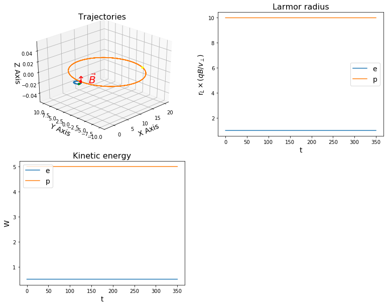

```python
crossEB(0,0,225)
```

Then we introduce an electric field on the xy plan, $\vec{E}=1\vec{u}_x+1\vec{u}_y$:

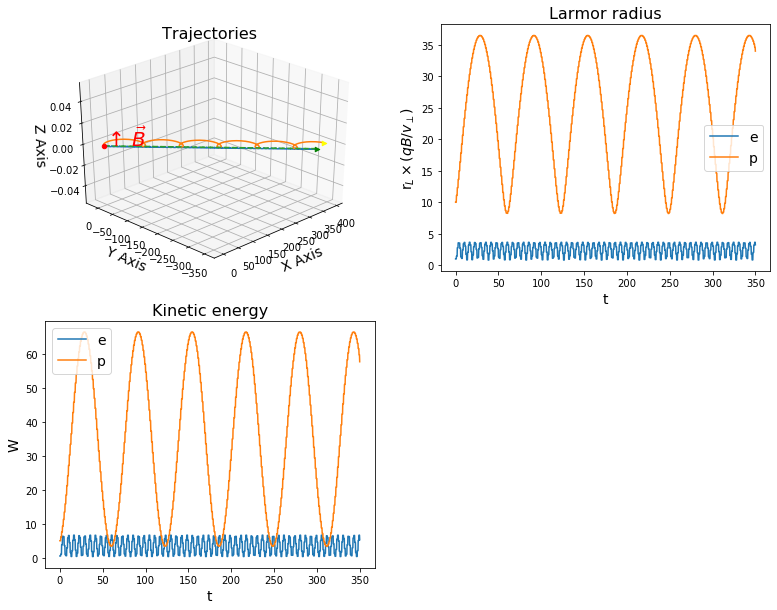

```python
crossEB(1,0,225)
```

And finally we add a z component to the electric field:

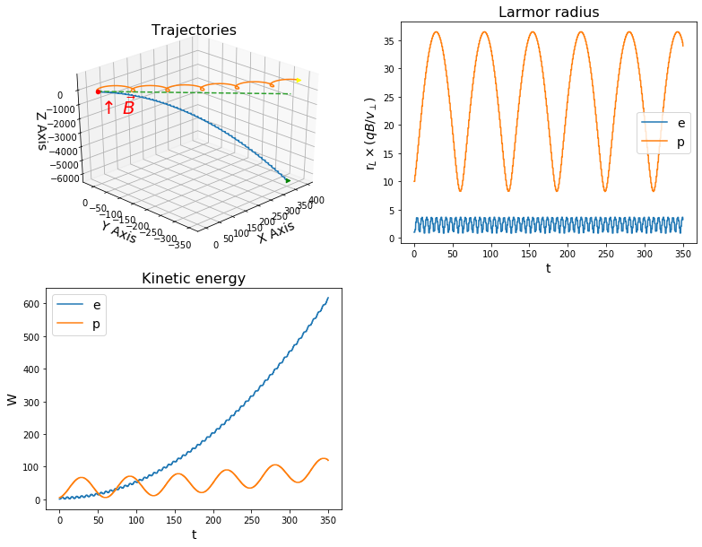

```python
crossEB(1,0.1,225)
```

# 5. General force, $\vec{F}$

The result above can be generalized for any constant and uniform force such that $\vec{F}\cdot\vec{B} = 0$:

$$ \vec{v}_{d} = \frac{\vec{F}\times\vec{B}}{q B^2}$$

In particular, for the gravitational field, we have a drift

$$\vec{v}_g = \frac{m}{q}\frac{\vec{g}\times\vec{B}}{B^2}$$

In this case **the direction of drift depends on the signal of** $q \Rightarrow$ for positive and negative charges, we have a current!

# Appendix - Useful vector formulae

$$ \vec{A}\times(\vec{B}\times\vec{C}) = (\vec{A}\cdot\vec{C})\vec{B}-(\vec{A}\cdot\vec{B})\vec{C} $$